# act_report

[figure not shown]

WeRateDogs is a Twitter account that rates people's dogs with a humorous comment about the dog. These ratings almost always have a denominator of 10. The numerators, though? Almost always greater than 10. 11/10, 12/10, 13/10, etc. Why? Because "they're good dogs Brent." WeRateDogs has over 4 million followers and has received international media coverage.

In this blog post I wll be analyzing the data I have for WeRateDogs so understand the relationship between the various dog stages (puppo, doggo, floofer or pupper) , the favorite count and the retweet count Some of the available information I have are as follows

- Tweet_id
- Retweet_count
- Favorite_count
- Dog_stage
- Dog_type as p1
- Predicton algorithms as p1_conf

Kindly see my below analysis

```python
# Importing libraries

import pandas as pd
import numpy as np
import matplotlib.pyplot as plt
import seaborn as sns
%matplotlib inline
import statsmodels.api as sm
```

```python
master =pd.read_csv('twitter_archive_master.csv')
master.head()
```

|  | tweet_id | timestamp | source | text | rating_numerator | rating_denominator | name | dog_stage | retweet_count | favorite_count | p1 | p1_conf | p1_dog |
| --- | --- | --- | --- | --- | --- | --- | --- | --- | --- | --- | --- | --- | --- |
| 0 | 892177421306343426 | 2017-08-01 00:17:27+00:00 | <a href="http://twitter.com/download/iphone" r... | This is Tilly. She's just checking pup on you.... | 13 | 10 | Tilly | NaN | 5681 | 31121 | chihuahua | 0.323581 | True |
| 1 | 891815181378084864 | 2017-07-31 00:18:03+00:00 | <a href="http://twitter.com/download/iphone" r... | This is Archie. He is a rare Norwegian Pouncin... | 12 | 10 | Archie | NaN | 3765 | 23431 | chihuahua | 0.716012 | True |
| 2 | 891327558926688256 | 2017-07-29 16:00:24+00:00 | <a href="http://twitter.com/download/iphone" r... | This is Franklin. He would like you to stop ca... | 12 | 10 | Franklin | NaN | 8449 | 37595 | basset | 0.555712 | True |
| 3 | 891087950875897856 | 2017-07-29 00:08:17+00:00 | <a href="http://twitter.com/download/iphone" r... | Here we have a majestic great white breaching ... | 13 | 10 | None | NaN | 2835 | 18946 | chesapeake_bay_retriever | 0.425595 | True |
| 4 | 890971913173991426 | 2017-07-28 16:27:12+00:00 | <a href="http://twitter.com/download/iphone" r... | Meet Jax. He enjoys ice cream so much he gets ... | 13 | 10 | Jax | NaN | 1844 | 11011 | appenzeller | 0.341703 | True |

#### Analyzing the dataset to find a relationship between the various dog stages (puppo, doggo, floofer or pupper) , the favorite count and tweet_count

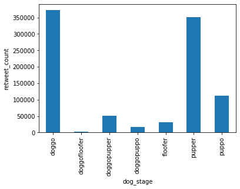

```python
# checkng the dog_stage with the highest retweet _count
master.groupby('dog_stage')['retweet_count'].sum().plot(kind='bar');
plt.ylabel('retweet_count')
```

This shows that the **doggo** dog_stage has more retweet count

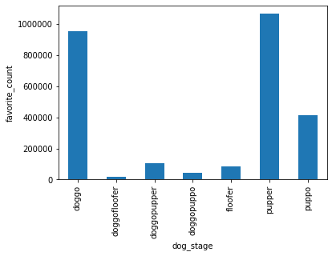

```python
# checkng the dog_stage with the highest favourite _count
master.groupby('dog_stage')['favorite_count'].sum().plot(kind='bar')
plt.ylabel('favorite_count')

plt.show()
```

This shows that the **pupper** dog_stage has more favorite count

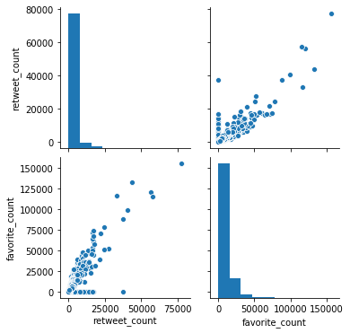

```python
#Checking the relationship between the retweet _count and the favourite _ count
df =master[['retweet_count','favorite_count']]
sns.pairplot(df,kind='scatter')
plt.show()
```

```python
#lets check the dog type tha has the highest retweet_count and favorite count
master.sort_values(by=['favorite_count'],ascending=False).head(2)
```

|  | tweet_id | timestamp | source | text | rating_numerator | rating_denominator | name | dog_stage | retweet_count | favorite_count | p1 | p1_conf | p1_dog |
| --- | --- | --- | --- | --- | --- | --- | --- | --- | --- | --- | --- | --- | --- |
| 661 | 744234799360020481 | 2016-06-18 18:26:18+00:00 | <a href="http://twitter.com/download/iphone" r... | Here's a doggo realizing you can stand in a po... | 13 | 10 | None | doggo | 77542 | 155620 | labrador_retriever | 0.825333 | True |
| 252 | 822872901745569793 | 2017-01-21 18:26:02+00:00 | <a href="http://twitter.com/download/iphone" r... | Here's a super supportive puppo participating ... | 13 | 10 | None | puppo | 43653 | 132637 | lakeland_terrier | 0.196015 | True |

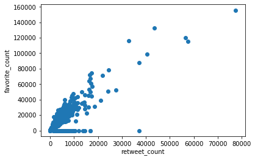

```python
plt.scatter(x=master['retweet_count'],y=master['favorite_count'])
plt.xlabel('retweet_count')
plt.ylabel('favorite_count')
plt.show()
```

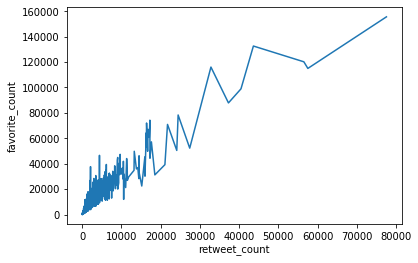

```python
#plt.plot(master['retweet_count'],master['favorite_count'])
#plt.show()
master.groupby('retweet_count')['favorite_count'].sum().plot(kind='line')
plt.xlabel('retweet_count')
plt.ylabel('favorite_count')
plt.show()
```

#### The scactter plot and the line plot shows a positive relattion ship between the favourite _count and the retweet_count

```python
#creating a copy of the data set
stage = master.copy()
```

```python
stage['dog_stage'].value_counts()
```

```
pupper          146
doggo            49
puppo            19
doggopupper      10
floofer           7
doggofloofer      1
doggopuppo        1
Name: dog_stage, dtype: int64
```

```python
#creatng a new datafram without the double stages(doggopupper,doggofloofer ,doggopuppo )
stage[(stage['dog_stage'] =='pupper')|(stage['dog_stage'] =='doggo')|(stage['dog_stage'] =='puppo')|(stage['dog_stage'] =='floofer')]
```

|  | tweet_id | timestamp | source | text | rating_numerator | rating_denominator | name | dog_stage | retweet_count | favorite_count | p1 | p1_conf | p1_dog |
| --- | --- | --- | --- | --- | --- | --- | --- | --- | --- | --- | --- | --- | --- |
| 7 | 890240255349198849 | 2017-07-26 15:59:51+00:00 | <a href="http://twitter.com/download/iphone" r... | This is Cassie. She is a college pup. Studying... | 14 | 10 | Cassie | doggo | 6663 | 29773 | pembroke | 0.511319 | True |
| 10 | 889665388333682689 | 2017-07-25 01:55:32+00:00 | <a href="http://twitter.com/download/iphone" r... | Here's a puppo that seems to be on the fence a... | 13 | 10 | None | puppo | 9088 | 44909 | pembroke | 0.966327 | True |
| 12 | 889531135344209921 | 2017-07-24 17:02:04+00:00 | <a href="http://twitter.com/download/iphone" r... | This is Stuart. He's sporting his favorite fan... | 13 | 10 | Stuart | puppo | 2049 | 14157 | golden_retriever | 0.953442 | True |
| 24 | 886366144734445568 | 2017-07-15 23:25:31+00:00 | <a href="http://twitter.com/download/iphone" r... | This is Roscoe. Another pupper fallen victim t... | 12 | 10 | Roscoe | pupper | 2880 | 19752 | french_bulldog | 0.999201 | True |
| 34 | 884162670584377345 | 2017-07-09 21:29:42+00:00 | <a href="http://twitter.com/download/iphone" r... | Meet Yogi. He doesn't have any important dog m... | 12 | 10 | Yogi | doggo | 2723 | 19074 | german_shepherd | 0.707046 | True |
| ... | ... | ... | ... | ... | ... | ... | ... | ... | ... | ... | ... | ... | ... |
| 1286 | 672622327801233409 | 2015-12-04 03:43:54+00:00 | <a href="http://twitter.com/download/iphone" r... | This lil pupper is sad because we haven't foun... | 12 | 10 | None | pupper | 465 | 1243 | golden_retriever | 0.952773 | True |
| 1288 | 672594978741354496 | 2015-12-04 01:55:13+00:00 | <a href="http://twitter.com/download/iphone" r... | Meet Scott. Just trying to catch his train to ... | 9 | 10 | Scott | pupper | 587 | 1285 | great_pyrenees | 0.755945 | True |
| 1293 | 672481316919734272 | 2015-12-03 18:23:34+00:00 | <a href="http://twitter.com/download/iphone" r... | Say hello to Jazz. She should be on the cover ... | 12 | 10 | Jazz | pupper | 123 | 691 | border_collie | 0.599454 | True |
| 1298 | 672254177670729728 | 2015-12-03 03:21:00+00:00 | <a href="http://twitter.com/download/iphone" r... | This is Rolf. He's having the time of his life... | 11 | 10 | Rolf | pupper | 707 | 1381 | pug | 0.979487 | True |
| 1304 | 672160042234327040 | 2015-12-02 21:06:56+00:00 | <a href="http://twitter.com/download/iphone" r... | This is Bubba. He's a Titted Peebles Aorta. Ev... | 8 | 10 | Bubba | pupper | 341 | 841 | pug | 0.561027 | True |

221 rows × 13 columns

```python
breed=stage[(stage['dog_stage'] =='pupper')|(stage['dog_stage'] =='doggo')|(stage['dog_stage'] =='puppo')|(stage['dog_stage'] =='floofer')]
```

```python
breed.head()
```

|  | tweet_id | timestamp | source | text | rating_numerator | rating_denominator | name | dog_stage | retweet_count | favorite_count | p1 | p1_conf | p1_dog |
| --- | --- | --- | --- | --- | --- | --- | --- | --- | --- | --- | --- | --- | --- |
| 7 | 890240255349198849 | 2017-07-26 15:59:51+00:00 | <a href="http://twitter.com/download/iphone" r... | This is Cassie. She is a college pup. Studying... | 14 | 10 | Cassie | doggo | 6663 | 29773 | pembroke | 0.511319 | True |
| 10 | 889665388333682689 | 2017-07-25 01:55:32+00:00 | <a href="http://twitter.com/download/iphone" r... | Here's a puppo that seems to be on the fence a... | 13 | 10 | None | puppo | 9088 | 44909 | pembroke | 0.966327 | True |
| 12 | 889531135344209921 | 2017-07-24 17:02:04+00:00 | <a href="http://twitter.com/download/iphone" r... | This is Stuart. He's sporting his favorite fan... | 13 | 10 | Stuart | puppo | 2049 | 14157 | golden_retriever | 0.953442 | True |
| 24 | 886366144734445568 | 2017-07-15 23:25:31+00:00 | <a href="http://twitter.com/download/iphone" r... | This is Roscoe. Another pupper fallen victim t... | 12 | 10 | Roscoe | pupper | 2880 | 19752 | french_bulldog | 0.999201 | True |
| 34 | 884162670584377345 | 2017-07-09 21:29:42+00:00 | <a href="http://twitter.com/download/iphone" r... | Meet Yogi. He doesn't have any important dog m... | 12 | 10 | Yogi | doggo | 2723 | 19074 | german_shepherd | 0.707046 | True |

```python
breed.shape
```

```
(221, 13)
```

```python
# dropping unwanted columns
breed.drop(['tweet_id','timestamp','source','text','rating_numerator','rating_denominator','name','p1','p1_conf','p1_dog'],axis= 1, inplace = True)
```

```python
breed.head()
```

|  | dog_stage | retweet_count | favorite_count |
| --- | --- | --- | --- |
| 7 | doggo | 6663 | 29773 |
| 10 | puppo | 9088 | 44909 |
| 12 | puppo | 2049 | 14157 |
| 24 | pupper | 2880 | 19752 |
| 34 | doggo | 2723 | 19074 |

```python
breed['dog_stage'].value_counts()
```

```
pupper     146
doggo       49
puppo       19
floofer      7
Name: dog_stage, dtype: int64
```

```python
#Creating dummy variables for our multilnnear model
breed[['doggo','puppo','pupper','floofer']]= pd.get_dummies(stage_df['dog_stage'])
```

```python
breed.head()
```

|  | dog_stage | retweet_count | favorite_count | doggo | puppo | pupper | floofer |
| --- | --- | --- | --- | --- | --- | --- | --- |
| 7 | doggo | 6663 | 29773 | 1 | 0 | 0 | 0 |
| 10 | puppo | 9088 | 44909 | 0 | 0 | 0 | 1 |
| 12 | puppo | 2049 | 14157 | 0 | 0 | 0 | 1 |
| 24 | pupper | 2880 | 19752 | 0 | 0 | 1 | 0 |
| 34 | doggo | 2723 | 19074 | 1 | 0 | 0 | 0 |

```python
breed['intercept'] = 1
lm = sm.OLS(breed['favorite_count'], breed[['intercept', 'doggo','pupper','floofer']])
results = lm.fit()
results.summary()
```

OLS Regression Results

| Dep. Variable: | favorite_count | R-squared: | 0.090 |
| --- | --- | --- | --- |
| Model: | OLS | Adj. R-squared: | 0.077 |
| Method: | Least Squares | F-statistic: | 7.128 |
| Date: | Sun, 28 Jun 2020 | Prob (F-statistic): | 0.000137 |
| Time: | 15:34:01 | Log-Likelihood: | -2488.5 |
| No. Observations: | 221 | AIC: | 4985. |
| Df Residuals: | 217 | BIC: | 4999. |
| Df Model: | 3 |  |  |
| Covariance Type: | nonrobust |  |  |

|  | coef | std err | t | P>\|t\| | [0.025 | 0.975] |
| --- | --- | --- | --- | --- | --- | --- |
| intercept | 1.201e+04 | 7168.273 | 1.676 | 0.095 | -2116.924 | 2.61e+04 |
| doggo | 7477.4898 | 7663.206 | 0.976 | 0.330 | -7626.355 | 2.26e+04 |
| pupper | -4707.3669 | 7338.103 | -0.641 | 0.522 | -1.92e+04 | 9755.714 |
| floofer | 9735.1504 | 8385.412 | 1.161 | 0.247 | -6792.131 | 2.63e+04 |

| Omnibus: | 236.443 | Durbin-Watson: | 2.086 |
| --- | --- | --- | --- |
| Prob(Omnibus): | 0.000 | Jarque-Bera (JB): | 6115.637 |
| Skew: | 4.448 | Prob(JB): | 0.00 |
| Kurtosis: | 27.187 | Cond. No. | 14.2 |

Warnings:  
[1] Standard Errors assume that the covariance matrix of the errors is correctly specified.

```python
#stage_df['intercept'] = 1
lm = sm.OLS(breed['retweet_count'], breed[['intercept', 'doggo','pupper','floofer']])
results = lm.fit()
results.summary()
```

OLS Regression Results

| Dep. Variable: | retweet_count | R-squared: | 0.068 |
| --- | --- | --- | --- |
| Model: | OLS | Adj. R-squared: | 0.056 |
| Method: | Least Squares | F-statistic: | 5.319 |
| Date: | Sun, 28 Jun 2020 | Prob (F-statistic): | 0.00148 |
| Time: | 15:46:09 | Log-Likelihood: | -2303.2 |
| No. Observations: | 221 | AIC: | 4614. |
| Df Residuals: | 217 | BIC: | 4628. |
| Df Model: | 3 |  |  |
| Covariance Type: | nonrobust |  |  |

|  | coef | std err | t | P>\|t\| | [0.025 | 0.975] |
| --- | --- | --- | --- | --- | --- | --- |
| intercept | 4340.4286 | 3099.500 | 1.400 | 0.163 | -1768.551 | 1.04e+04 |
| doggo | 3255.8980 | 3313.505 | 0.983 | 0.327 | -3274.876 | 9786.671 |
| pupper | -1935.3258 | 3172.933 | -0.610 | 0.543 | -8189.039 | 4318.387 |
| floofer | 1558.8872 | 3625.781 | 0.430 | 0.668 | -5587.368 | 8705.142 |

| Omnibus: | 265.643 | Durbin-Watson: | 1.909 |
| --- | --- | --- | --- |
| Prob(Omnibus): | 0.000 | Jarque-Bera (JB): | 11094.761 |
| Skew: | 5.142 | Prob(JB): | 0.00 |
| Kurtosis: | 36.152 | Cond. No. | 14.2 |

Warnings:  
[1] Standard Errors assume that the covariance matrix of the errors is correctly specified.

### conclusion

There is a very weak correlation between dog_stage and retweet_count or favorite_count with R square value of 0.068 and 0.09 repectively